# Analysis 2

This script repeats many of the procedures found in Analysis 1, but using the data file with outliers removed.

The initial code is as before, so no comments will be provided.

```r
#=============================================================#
#                                                             #
# Analyze the CBT Nuggets Test Data Set - Outliers removed    #
# @author: Damian Satterthwaite-Phillips <damiansp@gmail.com> #
# @version: 23 Sep 2016                                       #
#                                                             #
#=============================================================#

# Clear workspace
rm(list = ls())

# Load libraries (assumes they have been installed)
library(mgcv) # for gam()
library(nlme) # for gls()

# Load any data stored from previous session
load('~/Desktop/cbtnuggetsbusinessanalyticsproject/revenue/nuggets2.RData')

# Store current best from previous files
currentBest <- list(mod = 'mod.lm2.outliersIn', sse = 13724509546)

# Outliers replaced with NAs
data2 <- read.csv(
  '~/Desktop/cbtnuggetsbusinessanalyticsproject/revenue/dataCleanNoOutlier.csv')

# Seed random number generator
set.seed(11)

# Convert binary data to categorical
data2$highseason   <- as.factor(data2$highseason)
data2$holiday      <- as.factor(data2$holiday)
data2$autoenroll   <- as.factor(data2$autoenroll)
data2$socialperson <- as.factor(data2$socialperson)
data2$promoteposts <- as.factor(data2$promoteposts)
data2$learner      <- as.factor(data2$learner)

# Convert 'Week' to Date type
data2$Week <- as.Date(data2$Week, format = '%m/%d/%y')


# Scale numerical data; DO NOT SCALE RESPONSE
# Rescale so all values are on the interval [0, 1]
rescale <- function(x) {
    x <- x - min(x, na.rm = T)
    x <- x / max(x, na.rm = T)
    return (x)
}

for (i in 3:ncol(data2)) {
  if (class(data2[, i]) != 'factor') {
    data2[, i] <- rescale(data2[, i])
  }
}

# Split data into train and test sets
# Put 29 rows (~25%) aside in test set
test2.inds <- sort(sample(1:nrow(data2), size = 29))

# In the test set, in order to be able to make predictions if there are NAs,
# replace NA's with values; Since these are time series with clear temporal
# autocorrelation, simplify by filling with the data from the previous date
for (j in 2:ncol(data2)) {
  for (i in 1:nrow(data2)) {
    if (i %in% test2.inds & is.na(data2[i, j])) {
      if (i == 1) {
        # first row has no prior date; use following
        data2[i, j] <- data2[i + 1, j]
      } else {
        data2[i, j] <- data2[i - 1, j]
      }
    }
  }
}

test2 <- data2[test2.inds, ]
train2 <- data2[-test2.inds, ]

# Fill remaining NAs
test2$rev2weekAgo[1:2] <- test2$rev2weekAgo[3]
test2$rev3weekAgo[1:2] <- test2$rev3weekAgo[3]
test2$rev4weekAgo[1:2] <- test2$rev4weekAgo[3]
```

### Basic linear model

Just as a baseline, do a simple linear model and check its predictions on the test2 set as a “score-to-beat”

```r
mod.lm1 <- lm(revenue ~ ., data = train2)
summary(mod.lm1)
```

```
##
## Call:
## lm(formula = revenue ~ ., data = train2)
##
## Residuals:
## ALL 46 residuals are 0: no residual degrees of freedom!
##
## Coefficients: (12 not defined because of singularities)
##                    Estimate Std. Error t value Pr(>|t|)
## (Intercept)        26430971         NA      NA       NA
## Week                  -1621         NA      NA       NA
## weekno                   NA         NA      NA       NA
## highseason1          125155         NA      NA       NA
## holiday1              67424         NA      NA       NA
## displayimp          -423164         NA      NA       NA
## displaylag          -781464         NA      NA       NA
## brandpaid             12372         NA      NA       NA
## brandclicks          -13646         NA      NA       NA
## nonbrandpaid         127788         NA      NA       NA
## nonbrandclicks      -140379         NA      NA       NA
## organicnew          -359117         NA      NA       NA
## youtube             -933970         NA      NA       NA
## youtubelag           350586         NA      NA       NA
## socialpostimp        -38571         NA      NA       NA
## socialpostlag     -21131640         NA      NA       NA
## socialimp           -157120         NA      NA       NA
## socialimplag        1149061         NA      NA       NA
## fbposts             -459594         NA      NA       NA
## Fbpostimp           -352939         NA      NA       NA
## Fbpostimplag       13726537         NA      NA       NA
## Fbpageimp                NA         NA      NA       NA
## Fblikes              842039         NA      NA       NA
## Fbengage            -137622         NA      NA       NA
## fbengagelag         -865878         NA      NA       NA
## twposts             -531938         NA      NA       NA
## Twpostimp                NA         NA      NA       NA
## TWimpLag            7420324         NA      NA       NA
## twengage             674830         NA      NA       NA
## twengagelag         -487693         NA      NA       NA
## emailsent            849784         NA      NA       NA
```

[output cut: 17 more lines]

```
## logSocialpostlag         NA         NA      NA       NA
## organicnew2         1795886         NA      NA       NA
## logOrganicnew            NA         NA      NA       NA
## blognewusers2            NA         NA      NA       NA
## blognewusersRecip        NA         NA      NA       NA
## Fbpostimplag2            NA         NA      NA       NA
## weekOfYear2              NA         NA      NA       NA
## sinWeekOfYear            NA         NA      NA       NA
## Twpostimp2               NA         NA      NA       NA
## logTwpostimp             NA         NA      NA       NA
##
## Residual standard error: NaN on 0 degrees of freedom
##   (42 observations deleted due to missingness)
## Multiple R-squared:      1,  Adjusted R-squared:    NaN
## F-statistic:   NaN on 45 and 0 DF,  p-value: NA
```

```r
# Remove linearly dependent variables, in order to be able to use predict
mod.lm1 <- update(mod.lm1,
                  . ~ . - weekno - Fbpageimp - Twpostimp - logSocialpostlag -
                  logOrganicnew - blognewusers2 - blognewusersRecip - Fbpostimplag2
                  - weekOfYear2 - sinWeekOfYear - Twpostimp2 - logTwpostimp)
summary(mod.lm1)
```

```
##
## Call:
## lm(formula = revenue ~ Week + highseason + holiday + displayimp +
##     displaylag + brandpaid + brandclicks + nonbrandpaid + nonbrandclicks +
##     organicnew + youtube + youtubelag + socialpostimp + socialpostlag +
##     socialimp + socialimplag + fbposts + Fbpostimp + Fbpostimplag +
##     Fblikes + Fbengage + fbengagelag + twposts + TWimpLag + twengage +
##     twengagelag + emailsent + emailopen + emailclick + blogvisits +
##     blognewusers + blogrefer + blogrefernew + blogsignup + autoenroll +
##     socialperson + promoteposts + learner + rev1weekAgo + rev2weekAgo +
##     rev3weekAgo + rev4weekAgo + weekOfYear + fbEngage3 + organicnew2,
##     data = train2)
##
## Residuals:
##         11         15         25         27         28         29
##  3.055e-13 -2.005e+01 -1.496e+03  3.492e+02  1.177e+03  9.010e+02
##         30         36         38         39         40         41
## -6.239e+02 -6.796e+02  2.963e+02 -9.260e+02  7.366e+02  9.495e+02
##         43         44         50         53         55         56
##  1.589e+02 -7.607e+02 -1.441e+02  8.350e+01 -2.527e+02  9.119e+02
##         58         62         65         67         68         70
## -1.017e+03  1.707e+03 -1.397e+03  7.091e+02 -6.976e+02 -3.086e+00
##         71         72         73         74         75         80
## -2.380e+02  7.720e+01  1.797e+03  2.182e+02 -1.816e+03  8.963e+02
##         82         83         85         86         87         91
##  4.866e+02 -8.736e+02  1.310e+03  2.163e+02 -3.009e+03 -3.526e+02
##         92         95         99        100        101        103
## -7.045e+02  2.345e+03 -9.651e+02  5.880e+02  6.345e+01  6.367e+02
##        104        106        108        113        116
##  1.593e+01 -1.305e+03  1.747e+02  1.468e+02  3.293e+02
##
## Coefficients:
##                  Estimate Std. Error t value Pr(>|t|)
## (Intercept)     2.356e+07  1.322e+07   1.783    0.325
## Week           -1.452e+03  8.151e+02  -1.781    0.326
## highseason1     1.123e+05  4.433e+04   2.532    0.239
## holiday1        7.177e+04  4.840e+04   1.483    0.378
## displayimp     -4.376e+05  2.211e+05  -1.979    0.298
## displaylag     -8.190e+05  2.283e+05  -3.587    0.173
## brandpaid       1.955e+03  7.118e+04   0.027    0.983
```

[output cut: 29 more lines]

```
## socialperson1   9.006e+04  8.837e+04   1.019    0.494
## promoteposts1  -1.216e+04  7.053e+04  -0.172    0.891
## learner1        6.381e+05  2.588e+05   2.466    0.245
## rev1weekAgo    -5.046e+04  7.094e+04  -0.711    0.606
## rev2weekAgo     1.321e+05  7.446e+04   1.774    0.327
## rev3weekAgo    -2.219e+05  1.400e+05  -1.585    0.358
## rev4weekAgo     1.892e+05  9.564e+04   1.979    0.298
## weekOfYear      1.348e+05  8.473e+04   1.591    0.357
## fbEngage3       3.820e+05  3.375e+05   1.132    0.461
## organicnew2     1.898e+05  1.230e+06   0.154    0.902
##
## Residual standard error: 6719 on 1 degrees of freedom
##   (41 observations deleted due to missingness)
## Multiple R-squared:  0.9982, Adjusted R-squared:  0.9159
## F-statistic: 12.13 on 45 and 1 DF,  p-value: 0.2246
```

```r
mod.lm1.p <- predict(mod.lm1, newdata = test2)

# Compare predictions to actual values
cbind(mod.lm1.p, test2$revenue)
```

```
##      mod.lm1.p
## 1    474561.21 178480
## 2    524448.61 185390
## 6    241474.99 158310
## 8    305027.85 150630
## 10   336142.38 139820
## 12   153885.11 137330
## 14   161362.78 123550
## 16   -72314.82 130580
## 19   375137.30 141100
## 20   -23746.63 131490
## 32   325896.98 167070
## 33   146186.22 138700
## 34   649855.33 121510
## 35    15929.41 145790
## 37   101056.93 143450
## 45   199771.22 179800
## 47  -246689.46  89490
## 48    68125.75  88760
## 49    16225.33 165910
## 59    31897.71 193570
## 66   411000.24 167480
## 76   -41963.11 115380
## 89    63839.95 164140
## 96   373806.98 128220
## 107  198694.91 153360
## 109  201795.39 158350
## 114 -278368.68 179530
## 115 -226780.47 146220
## 117 -617181.77 183050
```

```r
# Metric for quantifying fit (sum of squared error)
sse <- function(preds, actual) {
  return (sum((preds - actual)^2))
}

(mod.lm1.sse <- sse(mod.lm1.p, test2$revenue)) # 2.0267e+12
```

```
## [1] 2.026687e+12
```

```r
# To think about this number in terms of our response variable, we can calculate the
# average error:
sqrt(mod.lm1.sse / nrow(test2))
```

```
## [1] 264359.2
```

```r
sd(data2$revenue)
```

```
## [1] 23944.52
```

```r
# i.e., the average error in the predictions is $264,359; considerably more than the sd.  Obviously a poor fit.

# Check model against previous best
currentBest$sse     # 1.3725e+10
```

```
## [1] 13724509546
```

### Reduce model to prevent overfitting

```r
mod.lm2 <- step(mod.lm1, direction = 'both', trace = 0)
```

```
## Error in step(mod.lm1, direction = "both", trace = 0): number of rows in use has changed: remove missing values?
```

```r
mod.lm2 <- update(mod.lm1, . ~ . - brandpaid)
mod.lm2 <- step(mod.lm2, direction = 'both', trace = 0)
```

```
## Error in step(mod.lm2, direction = "both", trace = 0): number of rows in use has changed: remove missing values?
```

```r
mod.lm2 <- update(mod.lm2, . ~ . - socialpostimp - socialperson)
mod.lm2 <- step(mod.lm2, direction = 'both', trace = 0)
```

```
## Error in step(mod.lm2, direction = "both", trace = 0): number of rows in use has changed: remove missing values?
```

```r
mod.lm2 <- update(mod.lm2, . ~ . - emailclick - nonbrandclicks)
mod.lm2 <- step(mod.lm2, direction = 'both', trace = 0)
```

```
## Error in step(mod.lm2, direction = "both", trace = 0): number of rows in use has changed: remove missing values?
```

```r
mod.lm2 <- update(mod.lm2, . ~ . - learner - socialimp)
mod.lm2 <- step(mod.lm2, direction = 'both', trace = 0)
```

```
## Error in step(mod.lm2, direction = "both", trace = 0): number of rows in use has changed: remove missing values?
```

```r
mod.lm2 <- update(mod.lm2,
                  . ~ . - rev2weekAgo - rev3weekAgo - brandclicks)
mod.lm2 <- step(mod.lm2, direction = 'both', trace = 0)
```

```
## Error in step(mod.lm2, direction = "both", trace = 0): number of rows in use has changed: remove missing values?
```

```r
mod.lm2 <- update(mod.lm2, . ~ . - displayimp)
mod.lm2 <- step(mod.lm2, direction = 'both', trace = 0)
```

```
## Error in step(mod.lm2, direction = "both", trace = 0): number of rows in use has changed: remove missing values?
```

```r
mod.lm2 <- update(mod.lm2, . ~ . - Fblikes - rev4weekAgo)
mod.lm2 <- step(mod.lm2, direction = 'both', trace = 0)
```

```
## Error in step(mod.lm2, direction = "both", trace = 0): number of rows in use has changed: remove missing values?
```

```r
mod.lm2 <- update(mod.lm2, . ~ . - blognewusers)
mod.lm2 <- step(mod.lm2, direction = 'both', trace = 0)
```

```
## Error in step(mod.lm2, direction = "both", trace = 0): number of rows in use has changed: remove missing values?
```

```r
mod.lm2 <- update(mod.lm2, . ~ . - emailsent)
mod.lm2 <- step(mod.lm2, direction = 'both', trace = 0)
```

```
## Error in step(mod.lm2, direction = "both", trace = 0): number of rows in use has changed: remove missing values?
```

```r
mod.lm2 <- update(mod.lm2, . ~ . - twengage - fbposts)
mod.lm2 <- step(mod.lm2, direction = 'both', trace = 0)
```

```
## Error in step(mod.lm2, direction = "both", trace = 0): number of rows in use has changed: remove missing values?
```

```r
mod.lm2 <- update(mod.lm2, . ~ . - nonbrandpaid)
mod.lm2 <- step(mod.lm2, direction = 'both', trace = 0)
```

```
## Error in step(mod.lm2, direction = "both", trace = 0): number of rows in use has changed: remove missing values?
```

```r
mod.lm2 <- update(mod.lm2, . ~ . - blogvisits)
mod.lm2 <- step(mod.lm2, direction = 'both', trace = 0)
```

```
## Error in step(mod.lm2, direction = "both", trace = 0): number of rows in use has changed: remove missing values?
```

```r
mod.lm2 <- update(mod.lm2, . ~ . - weekOfYear - twposts - organicnew - emailopen)
mod.lm2 <- step(mod.lm2, direction = 'both', trace = 0)
mod.lm2 <- update(mod.lm2, . ~ . - displaylag)
mod.lm2 <- step(mod.lm2, direction = 'both', trace = 0)
summary(mod.lm2)
```

```
##
## Call:
## lm(formula = revenue ~ highseason + holiday + youtube + youtubelag +
##     socialpostlag + socialimplag + Fbpostimp + Fbpostimplag +
##     Fbengage + fbengagelag + TWimpLag + twengagelag + blogrefer +
##     blogrefernew + blogsignup + autoenroll + promoteposts + rev1weekAgo +
##     fbEngage3 + organicnew2, data = train2)
##
## Residuals:
##    Min     1Q Median     3Q    Max
## -19853  -6316  -1246   7063  18527
##
## Coefficients:
##               Estimate Std. Error t value Pr(>|t|)
## (Intercept)      94551       9758   9.690 7.04e-13 ***
## highseason1      39713       8286   4.793 1.63e-05 ***
## holiday1        -25647       7773  -3.299 0.001832 **
## youtube         -63044      30936  -2.038 0.047096 *
## youtubelag       36982      22043   1.678 0.099904 .
## socialpostlag -1803857     440107  -4.099 0.000159 ***
## socialimplag    -54433      29622  -1.838 0.072315 .
## Fbpostimp       -57756      19822  -2.914 0.005408 **
## Fbpostimplag   1091404     280682   3.888 0.000310 ***
## Fbengage         87496      25705   3.404 0.001350 **
## fbengagelag      99137      40238   2.464 0.017385 *
## TWimpLag        783465     159877   4.900 1.13e-05 ***
## twengagelag     -66402      30486  -2.178 0.034339 *
## blogrefer        41377      23934   1.729 0.090279 .
## blogrefernew    -37350      22442  -1.664 0.102566
## blogsignup       11247       8555   1.315 0.194884
## autoenroll1      26309       8896   2.957 0.004802 **
## promoteposts1    18526       5825   3.181 0.002576 **
## rev1weekAgo     -24184      13173  -1.836 0.072575 .
## fbEngage3      -134193      40130  -3.344 0.001609 **
## organicnew2      85038      18368   4.630 2.81e-05 ***
## ---
## Signif. codes:  0 '***' 0.001 '**' 0.01 '*' 0.05 '.' 0.1 ' ' 1
##
## Residual standard error: 10880 on 48 degrees of freedom
##   (19 observations deleted due to missingness)
## Multiple R-squared:  0.8473, Adjusted R-squared:  0.7836
## F-statistic: 13.31 on 20 and 48 DF,  p-value: 2.407e-13
```

```r
mod.lm2.p <- predict(mod.lm2, newdata = test2)
(mod.lm2.sse <- sse(mod.lm2.p, test2$revenue)) # 9.4992e+9
```

```
## [1] 9499157243
```

```r
sqrt(mod.lm2.sse / nrow(test2))
```

```
## [1] 18098.54
```

```r
# Check against current best
currentBest$sse
```

```
## [1] 13724509546
```

```r
# A better model already... Replace
currentBest <- list(mod = 'mod.lm2', sse = mod.lm2.sse)


# Add in the variables that could not be explored in the initial model
mod.lm3 <- update(mod.lm2,
                  . ~ . + weekno + Fbpageimp + Twpostimp + logSocialpostlag +
                  logOrganicnew + blognewusers2 + blognewusersRecip + Fbpostimplag2
                  + weekOfYear2 + sinWeekOfYear + Twpostimp2 + logTwpostimp)
# And reduce again
mod.lm3 <- step(mod.lm3, direction = 'both', trace = 0)
```

```
## Error in step(mod.lm3, direction = "both", trace = 0): number of rows in use has changed: remove missing values?
```

```r
mod.lm3 <- update(mod.lm3,
                  . ~ . - Fbpostimplag2 - blognewusers2 - logTwpostimp -
                  logOrganicnew - blogrefernew)
mod.lm3 <- step(mod.lm3, direction = 'both', trace = 0)
summary(mod.lm3)
```

```
##
## Call:
## lm(formula = revenue ~ highseason + holiday + youtube + youtubelag +
##     socialpostlag + socialimplag + Fbpostimp + Fbpostimplag +
##     Fbengage + fbengagelag + TWimpLag + twengagelag + blogrefer +
##     blogsignup + autoenroll + promoteposts + rev1weekAgo + fbEngage3 +
##     organicnew2 + weekno + Fbpageimp + Twpostimp + blognewusersRecip +
##     weekOfYear2 + sinWeekOfYear + Twpostimp2, data = train2)
##
## Residuals:
##      Min       1Q   Median       3Q      Max
## -16448.3  -6162.6   -435.8   5711.8  19266.2
##
## Coefficients:
##                   Estimate Std. Error t value Pr(>|t|)
## (Intercept)          53542      21175   2.528 0.015505 *
## highseason1          27678      10421   2.656 0.011302 *
## holiday1            -31922       7830  -4.077 0.000211 ***
## youtube             -84772      40422  -2.097 0.042345 *
## youtubelag           59487      27091   2.196 0.033964 *
## socialpostlag     -1517399     424510  -3.574 0.000934 ***
## socialimplag        -97084      45612  -2.128 0.039507 *
## Fbpostimp           -54556      22108  -2.468 0.017975 *
## Fbpostimplag        902828     270920   3.332 0.001862 **
## Fbengage             76683      26266   2.919 0.005735 **
## fbengagelag         148892      52468   2.838 0.007101 **
## TWimpLag            708166     162220   4.365 8.71e-05 ***
## twengagelag        -100309      34046  -2.946 0.005341 **
## blogrefer            21798      18684   1.167 0.250261
## blogsignup            9525       8569   1.112 0.272958
## autoenroll1          17162       9671   1.775 0.083562 .
## promoteposts1        11096       6424   1.727 0.091838 .
## rev1weekAgo         -27285      13466  -2.026 0.049449 *
## fbEngage3          -156899      46356  -3.385 0.001607 **
## organicnew2          72342      23625   3.062 0.003919 **
## weekno               59050      40610   1.454 0.153730
## Fbpageimp            20701      14305   1.447 0.155660
## Twpostimp            69770      43388   1.608 0.115697
## blognewusersRecip    25294      12564   2.013 0.050866 .
## weekOfYear2         -24337      18600  -1.308 0.198194
## sinWeekOfYear        21864      19204   1.138 0.261686
## Twpostimp2          -62676      36672  -1.709 0.095182 .
## ---
## Signif. codes:  0 '***' 0.001 '**' 0.01 '*' 0.05 '.' 0.1 ' ' 1
##
## Residual standard error: 10250 on 40 degrees of freedom
##   (21 observations deleted due to missingness)
## Multiple R-squared:  0.8787, Adjusted R-squared:  0.7998
## F-statistic: 11.14 on 26 and 40 DF,  p-value: 2.482e-11
```

```r
mod.lm3.p <- predict(mod.lm3, newdata = test2)
(mod.lm3.sse <- sse(mod.lm3.p, test2$revenue)) # 8.8486e+9
```

```
## [1] 8848615992
```

```r
sqrt(mod.lm3.sse / nrow(test2))
```

```
## [1] 17467.82
```

```r
currentBest$sse  # Improved again
```

```
## [1] 9499157243
```

```r
currentBest <- list(mod = 'mod.lm3', sse = mod.lm3.sse)
```

### Explore potential interaction terms

```r
# Do not include binary variables at this point
binVars <- c(
  'highseason', 'holiday', 'autoenroll', 'socialperson', 'promoteposts', 'learner')
predictors <- predictors[-which(predictors %in% binVars)]

# Also exclude Week, weekno from predictors here, as these will always be unique
# values (never repeated), so we don't want extrapolate
predictors <- predictors[-c(1, 2)]

#bestAIC <- c(Inf, Inf, Inf)
#bestInteractionMods <-  c('', '', '')
iterations <- 10 # limited to 10 for knitting purposes

for (i in 1:iterations) {
  sampP <- c()
  dfRemaining <- sample(50, 1)

  while (dfRemaining > 0) {
    preds <- sort(sample(predictors, 2))
    preds[3] <- paste(preds[1], preds[2], sep = ':')

    for (p in preds) {
      if (!(p %in% sampP)) {
        sampP <- c(sampP, p)
        dfRemaining <- dfRemaining - 1
      }
    }
  }

  if (length(sampP) > 50) {
    sampP <- sampP[-c(50:length(sampP))]
  }

  form <- 'revenue ~'

  for (p in sampP) {
    form <- paste(form, p, sep = ' + ')
  }

  mod <- lm(as.formula(form), data = train2)
  summary(mod)
  aic <- extractAIC(mod)[2]

  if (aic == -Inf) {
    # bad model
    continue
  } else {
    if (aic < bestAIC[3]) {
      if (aic < bestAIC[2]) {
        if (aic < bestAIC[1]) {
          # insert in first place, bump others
          bestAIC[3] <- bestAIC[2]
          bestAIC[2] <- bestAIC[1]
          bestAIC[1] <- aic
          bestInteractionMods[3] <- bestInteractionMods[2]
          bestInteractionMods[2] <- bestInteractionMods[1]
          bestInteractionMods[1] <- form
        } else {
          # insert in second place, bump other
          bestAIC[3] <- bestAIC[2]
          bestAIC[2] <- aic
          bestInteractionMods[3] <- bestInteractionMods[2]
          bestInteractionMods[2] <- form
        }
      } else {
        # insert in third place; no bumping
        bestAIC[3] <- aic
        bestInteractionMods[3] <- form
      }
    }
  }
}
```

```
## Error in sample.int(length(x), size, replace, prob): invalid first argument
```

```r
bestAIC
```

```
## [1] 922.7742 931.2489 933.7143
```

```r
#bestInteractionMods


bestInteractionMod3 <- lm(as.formula(bestInteractionMods[3]), data = train2)
bestInteractionMod2 <- lm(as.formula(bestInteractionMods[2]), data = train2)
bestInteractionMod1 <- lm(as.formula(bestInteractionMods[1]), data = train2)

# Reduce
bestInteractionMod3 <- step(bestInteractionMod3, trace = 0)
bestInteractionMod2 <- step(bestInteractionMod2, trace = 0)
bestInteractionMod1 <- step(bestInteractionMod1, trace = 0)
```

```
## Error in step(bestInteractionMod1, trace = 0): number of rows in use has changed: remove missing values?
```

```r
bestInteractionMod1 <- update(
  bestInteractionMod1,
  . ~ . - socialpostlag:emailclick - nonbrandclicks:fbposts -
  displayimp:logSocialpostlag - fbposts)
bestInteractionMod1 <- step(bestInteractionMod1, trace = 0)
```

```
## Error in step(bestInteractionMod1, trace = 0): number of rows in use has changed: remove missing values?
```

```r
bestInteractionMod1 <- update(
  bestInteractionMod1,
  . ~ . - rev2weekAgo:socialimp - Fbpostimp:youtubelag - Fbpostimp:nonbrandclicks -
  nonbrandclicks)
bestInteractionMod1 <- step(bestInteractionMod1, trace = 0)

summary(bestInteractionMod3)
```

```
##
## Call:
## lm(formula = revenue ~ +blogrefer + twposts + blogrefer:twposts +
##     emailclick + emailclick:twposts + emailopen + emailsent +
##     emailopen:emailsent + Fbengage + nonbrandpaid + Fbengage:nonbrandpaid +
##     fbengagelag + emailopen:fbengagelag + weekOfYear + emailclick:weekOfYear +
##     displayimp + twengagelag + displayimp:twengagelag + Fbpostimplag2 +
##     socialpostimp + Fbpostimplag2:socialpostimp + blognewusers +
##     TWimpLag + blognewusers:TWimpLag + Fbpostimplag + socialpostlag +
##     Fbpostimplag:socialpostlag + brandpaid + fbposts + brandpaid:fbposts +
##     Fbpostimp + socialimplag + Fbpostimp:socialimplag + brandclicks +
##     organicnew + brandclicks:organicnew + rev4weekAgo + twengage +
##     rev4weekAgo:twengage + organicnew2 + youtube + organicnew2:youtube +
##     Twpostimp + Twpostimp:youtube + Twpostimp2 + weekOfYear2 +
##     Twpostimp2:weekOfYear2 + blogvisits + blogvisits:twengagelag,
##     data = train2)
##
## Residuals:
##     Min      1Q  Median      3Q     Max
## -3532.5  -664.9    70.7   781.4  5930.9
##
## Coefficients: (1 not defined because of singularities)
##                             Estimate Std. Error t value Pr(>|t|)
## (Intercept)                  -126095      44553  -2.830 0.022143 *
## blogrefer                    -147143      45983  -3.200 0.012613 *
## twposts                       -86130      49900  -1.726 0.122614
## emailclick                    192809      37323   5.166 0.000857 ***
## emailopen                     -88419      65475  -1.350 0.213838
## emailsent                     105822      56884   1.860 0.099883 .
## Fbengage                       49090      47374   1.036 0.330404
## nonbrandpaid                   11788      10306   1.144 0.285773
## fbengagelag                  -460175      82034  -5.610 0.000505 ***
## weekOfYear                    756992     131413   5.760 0.000424 ***
## displayimp                    157568      41846   3.765 0.005501 **
## twengagelag                    49240      67466   0.730 0.486306
## Fbpostimplag2                3505142     497595   7.044 0.000108 ***
## socialpostimp                 352120     146122   2.410 0.042524 *
## blognewusers                  446055     108744   4.102 0.003429 **
## TWimpLag                      380192     134365   2.830 0.022166 *
## Fbpostimplag                  240890     327554   0.735 0.483085
```

[output cut: 25 more lines]

```
## brandpaid:fbposts             579969     175891   3.297 0.010902 *
## Fbpostimp:socialimplag        243348     138094   1.762 0.116058
## brandclicks:organicnew       -342891      71145  -4.820 0.001322 **
## rev4weekAgo:twengage          511777      59145   8.653 2.47e-05 ***
## organicnew2:youtube           215062     112094   1.919 0.091313 .
## youtube:Twpostimp            -224170      94561  -2.371 0.045201 *
## Twpostimp2:weekOfYear2        114968      60764   1.892 0.095125 .
## twengagelag:blogvisits       -529513     100514  -5.268 0.000757 ***
## ---
## Signif. codes:  0 '***' 0.001 '**' 0.01 '*' 0.05 '.' 0.1 ' ' 1
##
## Residual standard error: 4232 on 8 degrees of freedom
##   (31 observations deleted due to missingness)
## Multiple R-squared:  0.9953, Adjusted R-squared:  0.9672
## F-statistic: 35.36 on 48 and 8 DF,  p-value: 7.797e-06
```

```r
bestInteractionMod3 <- update(bestInteractionMod3, . ~ . - Fbpostimp)
summary(bestInteractionMod3)
```

```
##
## Call:
## lm(formula = revenue ~ blogrefer + twposts + emailclick + emailopen +
##     emailsent + Fbengage + nonbrandpaid + fbengagelag + weekOfYear +
##     displayimp + twengagelag + Fbpostimplag2 + socialpostimp +
##     blognewusers + TWimpLag + Fbpostimplag + socialpostlag +
##     brandpaid + fbposts + socialimplag + brandclicks + organicnew +
##     rev4weekAgo + twengage + organicnew2 + youtube + Twpostimp +
##     Twpostimp2 + weekOfYear2 + blogvisits + blogrefer:twposts +
##     twposts:emailclick + emailopen:emailsent + Fbengage:nonbrandpaid +
##     emailopen:fbengagelag + emailclick:weekOfYear + displayimp:twengagelag +
##     Fbpostimplag2:socialpostimp + blognewusers:TWimpLag + Fbpostimplag:socialpostlag +
##     brandpaid:fbposts + Fbpostimp:socialimplag + brandclicks:organicnew +
##     rev4weekAgo:twengage + organicnew2:youtube + youtube:Twpostimp +
##     Twpostimp2:weekOfYear2 + twengagelag:blogvisits, data = train2)
##
## Residuals:
##     Min      1Q  Median      3Q     Max
## -3532.5  -664.9    70.7   781.4  5930.9
##
## Coefficients:
##                             Estimate Std. Error t value Pr(>|t|)
## (Intercept)                  -126095      44553  -2.830 0.022143 *
## blogrefer                    -147143      45983  -3.200 0.012613 *
## twposts                       -86130      49900  -1.726 0.122614
## emailclick                    192809      37323   5.166 0.000857 ***
## emailopen                     -88419      65475  -1.350 0.213838
## emailsent                     105822      56884   1.860 0.099883 .
## Fbengage                       49090      47374   1.036 0.330404
## nonbrandpaid                   11788      10306   1.144 0.285773
## fbengagelag                  -460175      82034  -5.610 0.000505 ***
## weekOfYear                    756992     131413   5.760 0.000424 ***
## displayimp                    157568      41846   3.765 0.005501 **
## twengagelag                    49240      67466   0.730 0.486306
## Fbpostimplag2                3505142     497595   7.044 0.000108 ***
## socialpostimp                 181815      63869   2.847 0.021588 *
## blognewusers                  446055     108744   4.102 0.003429 **
## TWimpLag                      380192     134365   2.830 0.022166 *
## Fbpostimplag                  240890     327554   0.735 0.483085
## socialpostlag                 180728     514256   0.351 0.734338
```

[output cut: 23 more lines]

```
## brandpaid:fbposts             579969     175891   3.297 0.010902 *
## socialimplag:Fbpostimp        243348     138094   1.762 0.116058
## brandclicks:organicnew       -342891      71145  -4.820 0.001322 **
## rev4weekAgo:twengage          511777      59145   8.653 2.47e-05 ***
## organicnew2:youtube           215062     112094   1.919 0.091313 .
## youtube:Twpostimp            -224170      94561  -2.371 0.045201 *
## Twpostimp2:weekOfYear2        114968      60764   1.892 0.095125 .
## twengagelag:blogvisits       -529513     100514  -5.268 0.000757 ***
## ---
## Signif. codes:  0 '***' 0.001 '**' 0.01 '*' 0.05 '.' 0.1 ' ' 1
##
## Residual standard error: 4232 on 8 degrees of freedom
##   (31 observations deleted due to missingness)
## Multiple R-squared:  0.9953, Adjusted R-squared:  0.9672
## F-statistic: 35.36 on 48 and 8 DF,  p-value: 7.797e-06
```

```r
summary(bestInteractionMod2)
```

```
##
## Call:
## lm(formula = revenue ~ brandpaid + emailopen + logOrganicnew +
##     nonbrandpaid + blogvisits + TWimpLag + brandclicks + Twpostimp2 +
##     nonbrandclicks + weekOfYear + twposts + youtube + emailsent +
##     rev2weekAgo + youtubelag + blognewusers2 + weekOfYear2 +
##     socialpostimp + fbengagelag + socialimplag + displayimp +
##     Fblikes + blognewusers + Fbpostimplag2 + blogrefernew + rev1weekAgo +
##     fbposts + twengagelag + brandpaid:emailopen + blogvisits:TWimpLag +
##     brandclicks:Twpostimp2 + nonbrandclicks:weekOfYear + twposts:youtube +
##     blogvisits:emailsent + blogvisits:youtubelag + blognewusers2:weekOfYear2 +
##     twposts:socialpostimp + nonbrandclicks:fbengagelag + brandclicks:socialimplag +
##     displayimp:Fblikes + twposts:fbengagelag + blognewusers:Fbpostimplag2 +
##     fbposts:twengagelag, data = train2)
##
## Residuals:
##     Min      1Q  Median      3Q     Max
## -4813.2 -1174.5   -69.0   941.7  8651.6
##
## Coefficients:
##                            Estimate Std. Error t value Pr(>|t|)
## (Intercept)                   18736      52554   0.357 0.728862
## brandpaid                     42927      34552   1.242 0.242437
## emailopen                    131619      51216   2.570 0.027896 *
## logOrganicnew                208506      36332   5.739 0.000188 ***
## nonbrandpaid                 -11113      17937  -0.620 0.549392
## blogvisits                   288530      71632   4.028 0.002407 **
## TWimpLag                     146985      94143   1.561 0.149518
## brandclicks                   86513      35357   2.447 0.034443 *
## Twpostimp2                   263725      60903   4.330 0.001489 **
## nonbrandclicks               -92329      30364  -3.041 0.012448 *
## weekOfYear                  -261755      88931  -2.943 0.014701 *
## twposts                      -92739      41829  -2.217 0.050943 .
## youtube                     -201832      41063  -4.915 0.000609 ***
## emailsent                     94896      54726   1.734 0.113576
## rev2weekAgo                   15486      14616   1.060 0.314266
## youtubelag                   398115      58669   6.786 4.82e-05 ***
## blognewusers2                388886      84987   4.576 0.001017 **
## weekOfYear2                  170264      77215   2.205 0.051994 .
## socialpostimp                 64031      72299   0.886 0.396607
```

[output cut: 17 more lines]

```
## blognewusers2:weekOfYear2    108060      67158   1.609 0.138685
## twposts:socialpostimp       -124003     188785  -0.657 0.526105
## nonbrandclicks:fbengagelag   138833      55178   2.516 0.030592 *
## brandclicks:socialimplag    -107709      76090  -1.416 0.187288
## displayimp:Fblikes            52244      54839   0.953 0.363216
## twposts:fbengagelag          230583      76441   3.016 0.012973 *
## blognewusers:Fbpostimplag2   356041     102292   3.481 0.005915 **
## fbposts:twengagelag          963011      96902   9.938 1.68e-06 ***
## ---
## Signif. codes:  0 '***' 0.001 '**' 0.01 '*' 0.05 '.' 0.1 ' ' 1
##
## Residual standard error: 5289 on 10 degrees of freedom
##   (34 observations deleted due to missingness)
## Multiple R-squared:  0.9906, Adjusted R-squared:  0.9499
## F-statistic: 24.38 on 43 and 10 DF,  p-value: 3.79e-06
```

```r
summary(bestInteractionMod1)
```

```
##
## Call:
## lm(formula = revenue ~ organicnew2 + Twpostimp2 + rev1weekAgo +
##     socialpostlag + blognewusersRecip + blogrefernew + blognewusers2 +
##     TWimpLag + blognewusers + fbengagelag + emailclick + Fbpostimp +
##     youtubelag + emailopen + displayimp + logOrganicnew + Fbpageimp +
##     socialimplag + rev2weekAgo + socialimp + blogsignup + Fbpostimplag2 +
##     blogrefer + brandpaid + rev4weekAgo + blogvisits + emailsent +
##     organicnew2:Twpostimp2 + rev1weekAgo:socialpostlag + blognewusersRecip:blogrefernew +
##     blognewusers2:TWimpLag + blognewusers:fbengagelag + emailclick:emailopen +
##     Fbpostimp:logOrganicnew + Twpostimp2:logOrganicnew + logOrganicnew:Fbpageimp +
##     blognewusers2:socialimplag + blogsignup:Fbpostimplag2 + blogrefer:brandpaid +
##     Fbpostimplag2:rev4weekAgo + blogvisits:emailsent, data = train2)
##
## Residuals:
##     Min      1Q  Median      3Q     Max
## -9633.1 -1912.0  -534.2  1567.4 11611.9
##
## Coefficients:
##                                 Estimate Std. Error t value Pr(>|t|)
## (Intercept)                        89671      91732   0.978 0.343805
## organicnew2                       -13846     115240  -0.120 0.905963
## Twpostimp2                       1485212    1116971   1.330 0.203492
## rev1weekAgo                        73433      19442   3.777 0.001827 **
## socialpostlag                     344085     248849   1.383 0.186995
## blognewusersRecip                -260200      69488  -3.745 0.001953 **
## blogrefernew                      470658      94772   4.966 0.000169 ***
## blognewusers2                      58165     283327   0.205 0.840104
## TWimpLag                           87694      94645   0.927 0.368825
## blognewusers                     -948118     283968  -3.339 0.004487 **
## fbengagelag                      -163406      86015  -1.900 0.076867 .
## emailclick                         81981      57164   1.434 0.172052
## Fbpostimp                        1124562     292936   3.839 0.001610 **
## youtubelag                        -61924      32387  -1.912 0.075168 .
## emailopen                          86347      50771   1.701 0.109627
## displayimp                        -69086      26524  -2.605 0.019913 *
## logOrganicnew                     399864     134741   2.968 0.009583 **
## Fbpageimp                        -694883     338361  -2.054 0.057869 .
## socialimplag                       78786      48649   1.619 0.126176
## rev2weekAgo                       -38495      18897  -2.037 0.059683 .
```

[output cut: 14 more lines]

```
## Fbpostimp:logOrganicnew         -1726409     411131  -4.199 0.000774 ***
## Twpostimp2:logOrganicnew       -11237713    5077514  -2.213 0.042800 *
## logOrganicnew:Fbpageimp          -429405     117232  -3.663 0.002308 **
## blognewusers2:socialimplag        154352     114523   1.348 0.197734
## blogsignup:Fbpostimplag2         -718075     173884  -4.130 0.000891 ***
## blogrefer:brandpaid              -322517     113266  -2.847 0.012230 *
## Fbpostimplag2:rev4weekAgo        -178720      66824  -2.674 0.017322 *
## blogvisits:emailsent               77155      73711   1.047 0.311805
## ---
## Signif. codes:  0 '***' 0.001 '**' 0.01 '*' 0.05 '.' 0.1 ' ' 1
##
## Residual standard error: 8287 on 15 degrees of freedom
##   (31 observations deleted due to missingness)
## Multiple R-squared:  0.967,  Adjusted R-squared:  0.877
## F-statistic: 10.74 on 41 and 15 DF,  p-value: 6.196e-06
```

```r
bestInteractionMod3.p <- predict(bestInteractionMod3, test2)
bestInteractionMod2.p <- predict(bestInteractionMod2, test2)
bestInteractionMod1.p <- predict(bestInteractionMod1, test2)
(bestInteractionMod3.sse <- sse(bestInteractionMod3.p, test2$revenue)) # 1.2046e+11
```

```
## [1] 120458167929
```

```r
(bestInteractionMod2.sse <- sse(bestInteractionMod2.p, test2$revenue)) # 9.0065e+10
```

```
## [1] 90065062688
```

```r
(bestInteractionMod1.sse <- sse(bestInteractionMod1.p, test2$revenue)) # 6.4422e+11
```

```
## [1] 644220093096
```

```r
currentBest$sse  # NO improvement
```

```
## [1] 8848615992
```

```r
(sqrt(mod.lm3.sse / nrow(test2)))
```

```
## [1] 17467.82
```

```r
sd(data2$revenue)
```

```
## [1] 23944.52
```

The current best model, mod.lm3, has an average error of $17,468 now less than the standard deviation of $23,945 but we can do better. At this point though, it is reasonably clear that removing the outliers is improving the fit, so work will continue using this data set rather than the one with the outliers left in.

### Examine current best model diagnostics

Before moving on, check the current best model's diagnostics to see if there are any clear problems.

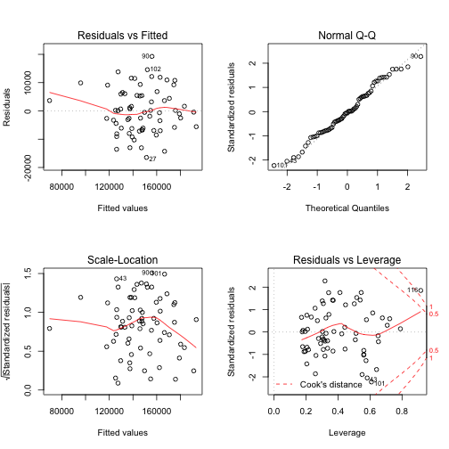

```r
par(mfrow = c(2, 2))
plot(mod.lm3)
```

```r
# Reasonably good diagnostics, though pt 116 clearly has disproportionate influence.
# Examine:
train2['116', ]
```

```
##     revenue       Week    weekno highseason holiday displayimp displaylag
## 116  148800 2016-04-17 0.9913793          0       0  0.5649609  0.9246011
##     brandpaid brandclicks nonbrandpaid nonbrandclicks organicnew   youtube
## 116 0.4450519   0.5532891    0.4035001      0.5134035  0.4339571 0.9047083
##     youtubelag socialpostimp socialpostlag socialimp socialimplag
## 116  0.8633105    0.06850587     0.1666849 0.4440168    0.9258737
##        fbposts  Fbpostimp Fbpostimplag Fbpageimp Fblikes  Fbengage
## 116 0.07692308 0.05542382    0.2013987 0.4385974       1 0.6711165
##     fbengagelag    twposts Twpostimp   TWimpLag   twengage twengagelag
## 116   0.4856438 0.03448276 0.0451389 0.06309587 0.06729544  0.01340811
##     emailsent emailopen emailclick blogvisits blognewusers blogrefer
## 116 0.1893037 0.3378021 0.09210029  0.3234939    0.3355759 0.4084084
##     blogrefernew blogsignup autoenroll socialperson promoteposts learner
## 116    0.3021739  0.1724138          1            1            1       1
##     rev1weekAgo rev2weekAgo rev3weekAgo rev4weekAgo weekOfYear fbEngage3
## 116    0.547351   0.7973135   0.4278103   0.4984241  0.2941176 0.1409195
##     logSocialpostlag organicnew2 logOrganicnew blognewusers2
## 116        0.1666849   0.3678097     0.5025766     0.2005084
##     blognewusersRecip Fbpostimplag2 weekOfYear2 sinWeekOfYear  Twpostimp2
## 116         0.3270903    0.05420777  0.09433962     0.3226976 0.002170291
##     logTwpostimp
## 116    0.5264517
```

```r
which(rownames(train2) == '116')
```

```
## [1] 88
```

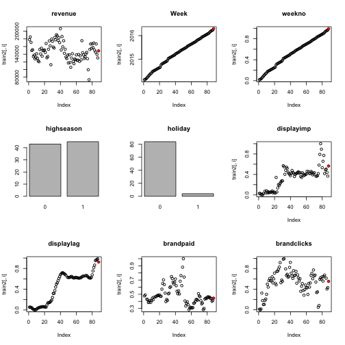

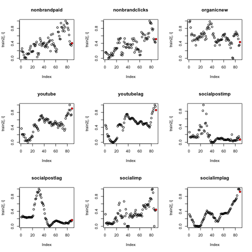

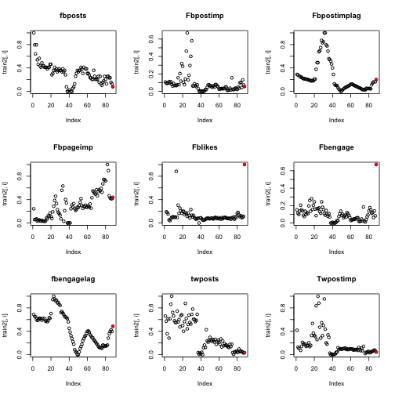

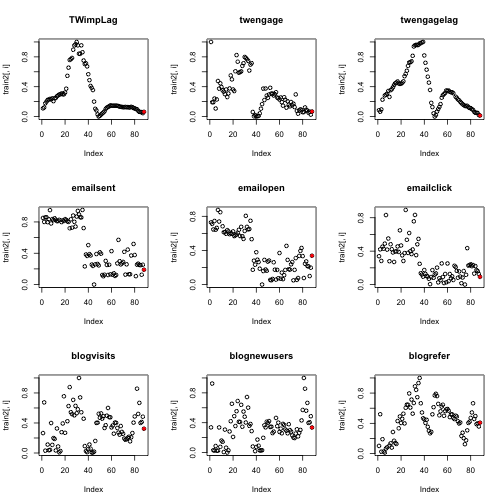

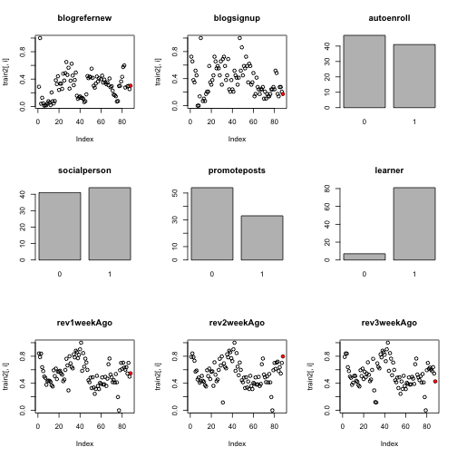

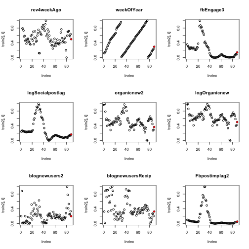

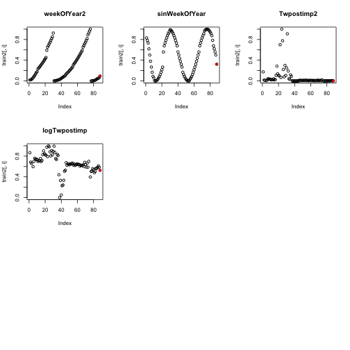

```r
par(mfrow = c(3, 3))
for (i in 1:ncol(train2)) {
  plot(train2[, i], main = names(train2)[i])
  points(88, train2[88, i], pch = 16, col = 2)
  if (i %% 9 == 0) { pause() }
}
```

This record has an unusually high value for both Fblikes and Fbengage. We can try transforming these predictors, or potentially removing these outliers

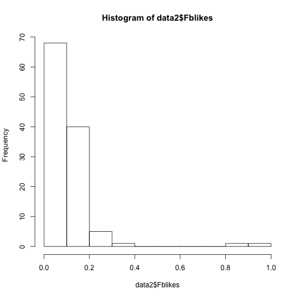

```r
hist(data2$Fblikes)
```

```r
sort(scale(data2$Fblikes))
```

```
##   [1] -1.015737932 -0.687947092 -0.613602778 -0.589947769 -0.576430621
##   [6] -0.576430621 -0.566292760 -0.532499890 -0.502086307 -0.478431298
##  [11] -0.471672724 -0.468293437 -0.454776289 -0.441259141 -0.427741993
##  [16] -0.414224845 -0.414224845 -0.414224845 -0.414224845 -0.410845558
##  [21] -0.410845558 -0.407466271 -0.390569836 -0.387190549 -0.387190549
##  [26] -0.387190549 -0.383811262 -0.383811262 -0.377052687 -0.373673400
##  [31] -0.366914826 -0.366914826 -0.363535539 -0.343259817 -0.343259817
##  [36] -0.333121956 -0.329742669 -0.326363382 -0.322984095 -0.322984095
##  [41] -0.319604808 -0.312846234 -0.312846234 -0.309466947 -0.302708373
##  [46] -0.299329086 -0.299329086 -0.295949799 -0.292570512 -0.292570512
##  [51] -0.292570512 -0.275674077 -0.268915503 -0.265536216 -0.258777642
##  [56] -0.252019068 -0.248639781 -0.241881207 -0.241881207 -0.228364059
##  [61] -0.221605485 -0.218226198 -0.218226198 -0.201329763 -0.197950476
##  [66] -0.197950476 -0.194571189 -0.181054041 -0.170916180 -0.164157606
##  [71] -0.157399032 -0.150640458 -0.143881884 -0.130364736 -0.123606162
##  [76] -0.103330440 -0.083054718 -0.083054718 -0.056020422 -0.052641135
##  [81] -0.052641135 -0.025606839 -0.005331117  0.014944605  0.031841041
##  [86]  0.041978902  0.041978902  0.041978902  0.048737476  0.096047494
##  [91]  0.096047494  0.109564642  0.183908956  0.268391131  0.275149705
##  [96]  0.275149705  0.302184001  0.346114732  0.356252593  0.386666176
## [101]  0.393424750  0.427217620  0.444114056  0.494803361  0.498182648
## [106]  0.602940545  0.646871276  0.653629850  0.677284859  0.704319155
## [111]  0.707698442  0.910455663  1.119971457  1.549140907  6.398417764
## [116]  7.378410997
```

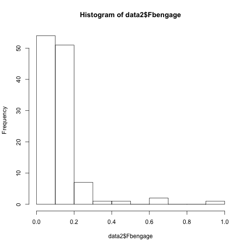

```r
hist(data2$Fbengage)
```

```r
sort(scale(data2$Fbengage))
```

```
##   [1] -0.954307233 -0.954307233 -0.954307233 -0.954307233 -0.954307233
##   [6] -0.954307233 -0.883049066 -0.872281166 -0.864046889 -0.819708474
##  [11] -0.813057712 -0.809257276 -0.792472019 -0.785821257 -0.769036000
##  [16] -0.758901505 -0.738315812 -0.736098892 -0.731981753 -0.692393883
##  [21] -0.667374349 -0.663890616 -0.644571735 -0.613534845 -0.603083647
##  [26] -0.589148717 -0.534992510 -0.534992510 -0.506805946 -0.500155184
##  [31] -0.490020689 -0.476719165 -0.476402462 -0.426363394 -0.424779879
##  [36] -0.420029335 -0.396593315 -0.391526068 -0.371257078 -0.368406752
##  [41] -0.330402396 -0.319317792 -0.295565070 -0.293348150 -0.281630140
##  [46] -0.278779813 -0.275612784 -0.261677853 -0.261361150 -0.258194121
##  [51] -0.252810170 -0.228740745 -0.213222300 -0.208471755 -0.192636607
##  [56] -0.188519469 -0.157799281 -0.151781925 -0.144814460 -0.143864351
##  [61] -0.129612718 -0.116311193 -0.114410975 -0.109660431 -0.061838284
##  [66] -0.054554116 -0.053920710 -0.051387086 -0.044102918 -0.043786215
##  [71] -0.028584473 -0.008632186  0.024621625  0.052491486  0.070226852
##  [76]  0.076877614  0.078777832  0.087962218  0.096196495  0.100313633
##  [81]  0.105697584  0.135467662  0.155736652  0.156686761  0.179172671
##  [86]  0.182973107  0.184873324  0.187723651  0.190257275  0.214643403
##  [91]  0.217177027  0.226044710  0.230161848  0.233328878  0.255814788
##  [96]  0.287801787  0.291602223  0.293502441  0.352725895  0.379328944
## [101]  0.417333299  0.434751962  0.453437437  0.456604467  0.533879990
## [106]  0.579801919  0.588036196  0.685264006  0.880986437  0.882886655
## [111]  1.003867186  1.147650332  1.991030322  2.457533786  4.124658183
## [116]  4.148727608  6.613626768
```

….continued in nuggetAnalysis3.R

```r
#save.image('~/Desktop/cbtnuggetsbusinessanalyticsproject/revenue/nuggets2.RData')
```